# Case1 PilgrimBank DanlingMa and XuyuanZhang

DanlingMa_XuyuanZhang

9/30/2018

# — 1) Introduction:—

## After reading the case, briefly describe Alan Green’s objectives of looking at customer profitability at Pilgrim Bank (200-300 words). (5 Points)

[output not shown]

# — 2) —

## a. Read in the “Data” page from the Pilgrim Bank Excel file into R. How many columns and rows are there in your data frame? (5 Points)

- There are 11 columns(variables) and 31634 rows(observations) in the pbdata.

```r
# Loading in 'data' sheet using 'sheet = 2'
pbdata = as.data.frame(read_excel('608715-XLS-ENG.xls', sheet = 2))
str(pbdata)
```

```
## 'data.frame':    31634 obs. of  11 variables:
##  $ ID       : num  1 2 3 4 5 6 7 8 9 10 ...
##  $ 9Profit  : num  21 -6 -49 -4 -61 -38 -19 59 493 -158 ...
##  $ 9Online  : num  0 0 1 0 0 0 0 0 0 0 ...
##  $ 9Age     : num  NA 6 5 NA 2 NA 3 5 4 6 ...
##  $ 9Inc     : num  NA 3 5 NA 9 3 1 8 9 8 ...
##  $ 9Tenure  : num  6.33 29.5 26.41 2.25 9.91 ...
##  $ 9District: num  1200 1200 1100 1200 1200 1300 1300 1200 1200 1100 ...
##  $ 0Profit  : num  NA -32 -22 NA -4 14 0 -65 855 -20 ...
##  $ 0Online  : num  NA 0 1 NA 0 0 0 0 0 0 ...
##  $ 9Billpay : num  0 0 0 0 0 0 0 0 0 0 ...
##  $ 0Billpay : num  NA 0 0 NA 0 0 0 0 0 0 ...
```

## b. Select the columns relating to customers’ 1999 variable. (5 Points)

```r
# Select 1999 data
pbdata_99 = select(pbdata, starts_with('I'), starts_with('9'))
#rename variables
names(pbdata_99) = c("ID", "Profit","Online", "Age", "Inc", "Tenure", "District", "Billpay")
```

# — 3) Data Description & Cleaning: (25 Points) —

## a. Describe the variables in your dataset via a summary()or str()command. In particular, state the “conceptual” measure types for each variable.

ID: Nominal

Profit: Ratio

Online: Nonimal

Age: Ordinal

Inc: Ordinal

Tenure: Ratio

District: Nominal

Billpay: Nominal

```r
# Data type
str(pbdata_99)
```

```
## 'data.frame':    31634 obs. of  8 variables:
##  $ ID      : num  1 2 3 4 5 6 7 8 9 10 ...
##  $ Profit  : num  21 -6 -49 -4 -61 -38 -19 59 493 -158 ...
##  $ Online  : num  0 0 1 0 0 0 0 0 0 0 ...
##  $ Age     : num  NA 6 5 NA 2 NA 3 5 4 6 ...
##  $ Inc     : num  NA 3 5 NA 9 3 1 8 9 8 ...
##  $ Tenure  : num  6.33 29.5 26.41 2.25 9.91 ...
##  $ District: num  1200 1200 1100 1200 1200 1300 1300 1200 1200 1100 ...
##  $ Billpay : num  0 0 0 0 0 0 0 0 0 0 ...
```

## b. There are missing values in customers’ age and income groups. Create a separate category in each of these variables that stands for missing age/income group information.

```r
addNA(pbdata_99$`Age`, ifany = TRUE)
addNA(pbdata_99$`Inc`, ifany = TRUE)
```

## c. If any of the variables are saved as the “wrong” data type in R, convert them to the “right” data type.

```r
pbdata_99$`Online` = as.factor(pbdata_99$`Online` )
pbdata_99$`Age` = factor(pbdata_99$`Age`, levels = c(1,2,3,4,5,6,7))
pbdata_99$`Inc` = factor(pbdata_99$`Inc`, levels = c(1,2,3,4,5,6,7,8,9))
pbdata_99$`Billpay` = as.factor(pbdata_99$`Billpay`)
pbdata_99$`ID` = as.integer(pbdata_99$`ID`)
pbdata_99$`District` = as.factor(pbdata_99$`District`)
str(pbdata_99)
```

```
## 'data.frame':    31634 obs. of  8 variables:
##  $ ID      : int  1 2 3 4 5 6 7 8 9 10 ...
##  $ Profit  : num  21 -6 -49 -4 -61 -38 -19 59 493 -158 ...
##  $ Online  : Factor w/ 2 levels "0","1": 1 1 2 1 1 1 1 1 1 1 ...
##  $ Age     : Factor w/ 7 levels "1","2","3","4",..: NA 6 5 NA 2 NA 3 5 4 6 ...
##  $ Inc     : Factor w/ 9 levels "1","2","3","4",..: NA 3 5 NA 9 3 1 8 9 8 ...
##  $ Tenure  : num  6.33 29.5 26.41 2.25 9.91 ...
##  $ District: Factor w/ 3 levels "1100","1200",..: 2 2 1 2 2 3 3 2 2 1 ...
##  $ Billpay : Factor w/ 2 levels "0","1": 1 1 1 1 1 1 1 1 1 1 ...
```

## d. Customers can be enrolled in online banking and electronic billpay facilities. Analyze the different combinations of subscriptions in these two services via a two-way frequency table.

```r
frequency_table = table(pbdata_99$`Online`, pbdata_99$`Billpay`)
colnames(frequency_table) = c('Not Electronic Billpay', 'Electronic billpay')
rownames(frequency_table) = c('Offline', 'Online')
frequency_table
```

```
##
##           Not Electronic Billpay Electronic billpay
##   Offline                  27780                  0
##   Online                    3326                528
```

## e. Create a new variable subscription_grp based on their subscriptions in online banking and electronic billpay. How many groups are there? Describe these groups briefly based on the results from part (d) above.

- **As we can see from the variable `category`, even though we have 4 levels, there are actually 3 groups:**

```r
pbdata_99$subscription_grp <-
  ifelse((pbdata_99$Online == "0") & (pbdata_99$Billpay == "0"), '00',
  ifelse((pbdata_99$Online == "0") & (pbdata_99$Billpay == "1"), '01',
  ifelse((pbdata_99$Online == "1") & (pbdata_99$Billpay == "0"), '10',
  '11')))
pbdata_99$subscription_grp = factor(pbdata_99$subscription_grp,
                                       levels = c('00', '01', '10', '11'),
                                       labels = c('Offline_NObillpay', 'Offline_Billpay',
                                                  'Online_NObillpay', 'Online_Billpay'))
category <- unique(pbdata_99$subscription_grp)
category
```

```
## [1] Offline_NObillpay Online_NObillpay  Online_Billpay
## 4 Levels: Offline_NObillpay Offline_Billpay ... Online_Billpay
```

# — 4) Visualizations: —

**We want to understand how customer profitability varies with customer demographics. For this analysis -**

## a. Show the distribution of profitability for customers’ income groups, age groups and districts. (10 Points)

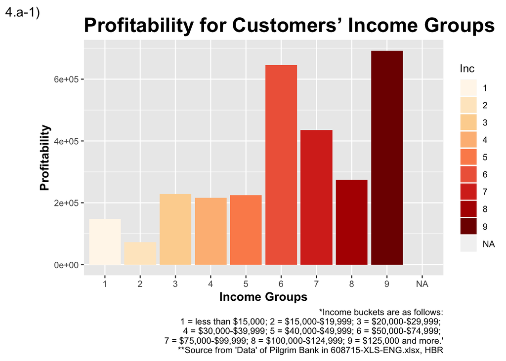

```r
#distribution of profitability for customers’ income groups
pbdata_99 %>%
  group_by(Inc)  %>%
  summarise(totalprofit = sum(Profit)) %>%
  ggplot(aes(x = Inc, y = totalprofit, fill = Inc)) +
  geom_col() +
  scale_fill_brewer(palette = "OrRd") +
  labs(  #add title and anotations
      title = 'Profitability for Customers’ Income Groups', tag = '4.a-1)', x = 'Income Groups', y = 'Profitability',       caption = "*Income buckets are as follows:
      1 = less than $15,000; 2 = $15,000-$19,999; 3 = $20,000-$29,999;
      4 = $30,000-$39,999; 5 = $40,000-$49,999; 6 = $50,000-$74,999;
      7 = $75,000-$99,999; 8 = $100,000-$124,999; 9 = $125,000 and more.'
      **Source from 'Data' of Pilgrim Bank in 608715-XLS-ENG.xlsx, HBR"
      ) +
  theme(  #formating font and size
      plot.title = element_text(size=20, face="bold"),
      axis.title.x = element_text(size=12, face="bold"),
      axis.title.y = element_text(size=12, face="bold")
      )
```

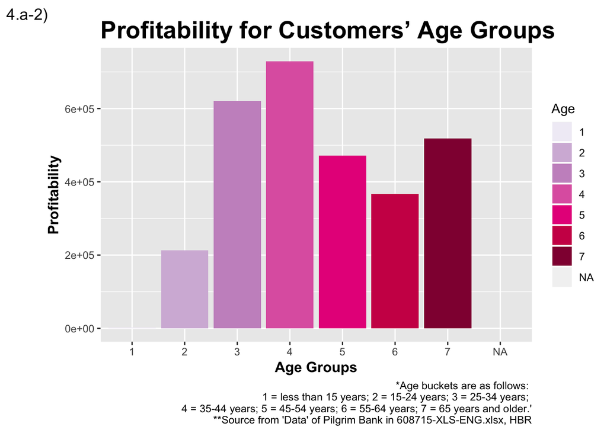

```r
#distribution of profitability for customers’ age groups
pbdata_99 %>%
  group_by(Age)  %>%
  summarise(totalprofit = sum(Profit)) %>%
  ggplot(aes(x = Age, y = totalprofit, fill = Age)) +
  geom_col() +
  scale_fill_brewer(palette = "PuRd") +
  labs(  #add title and anotations
      title = 'Profitability for Customers’ Age Groups', tag = '4.a-2)', x = 'Age Groups', y = 'Profitability',       caption = "*Age buckets are as follows:
      1 = less than 15 years; 2 = 15-24 years; 3 = 25-34 years;
      4 = 35-44 years; 5 = 45-54 years; 6 = 55-64 years; 7 = 65 years and older.'
      **Source from 'Data' of Pilgrim Bank in 608715-XLS-ENG.xlsx, HBR"
      ) +
  theme(  #formating font and size
      plot.title = element_text(size=20, face="bold"),
      axis.title.x = element_text(size=12, face="bold"),
      axis.title.y = element_text(size=12, face="bold")
      )
```

- From grahp 4.a-2), customers with age ranging from 25-44 drives profit the most. And customers with age less than 24 contributes to profit the least, it might be due to the income.

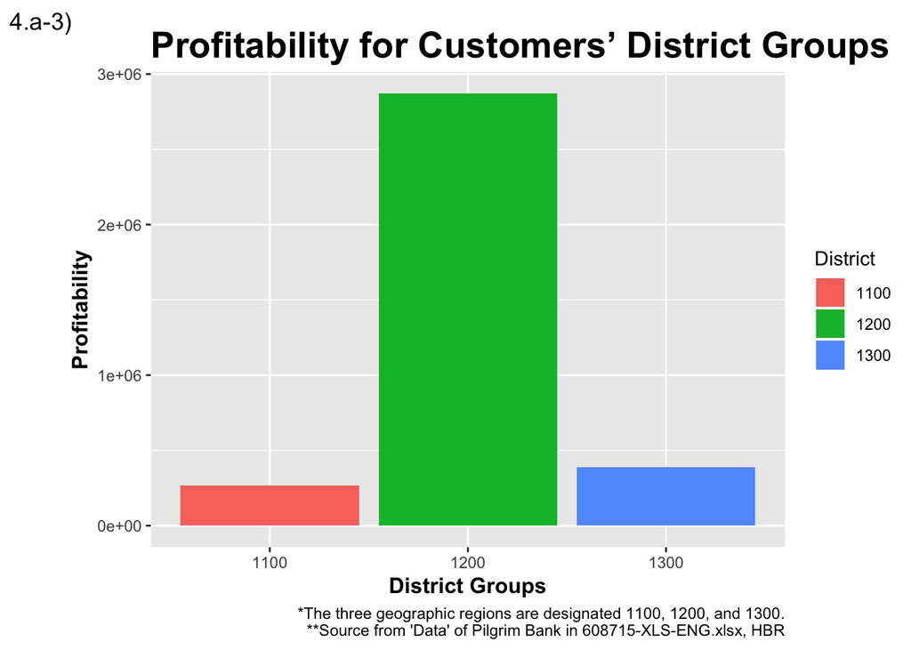

```r
#distribution of profitability for customers’ district groups
  pbdata_99 %>%
  group_by(District)  %>%
  summarise(totalprofit = sum(Profit)) %>%
  ggplot(aes(x = District, y = totalprofit, fill = District)) +
  geom_col()  +
  labs(  #add title and anotations
      title = 'Profitability for Customers’ District Groups', tag = '4.a-3)', x = 'District Groups', y = 'Profitability',       caption = "*The three geographic regions are designated 1100, 1200, and 1300.
      **Source from 'Data' of Pilgrim Bank in 608715-XLS-ENG.xlsx, HBR"
      ) +
  theme(  #formating font and size
      plot.title = element_text(size=20, face="bold"),
      axis.title.x = element_text(size=12, face="bold"),
      axis.title.y = element_text(size=12, face="bold")
      )
```

## b. Show the relationship between profitability and tenure (5 Points)

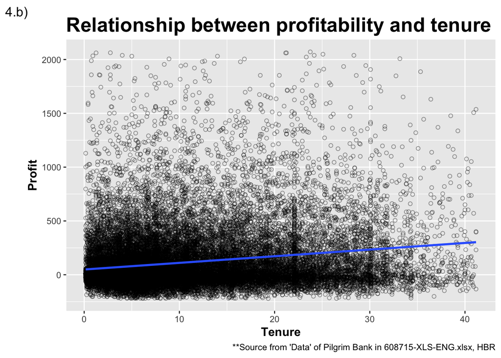

```r
ggplot(pbdata_99, aes(x = Tenure, y = Profit)) +
  geom_point(shape = 1, alpha = 0.4) +
  geom_smooth(method = lm) +
  labs(  #add title and anotations
      title = 'Relationship between profitability and tenure', tag = '4.b)', x = 'Tenure', y = 'Profit',       caption = "**Source from 'Data' of Pilgrim Bank in 608715-XLS-ENG.xlsx, HBR"
      ) +
  theme(  #formating font and size
      plot.title = element_text(size=20, face="bold"),
      axis.title.x = element_text(size=12, face="bold"),
      axis.title.y = element_text(size=12, face="bold")
      )
```

- From the scatter plot, there is slight positive relationship between the profit and tenure, the longer the tenure the higher the profit. But the profit is not significantly sensitive to the tenure period.

## c. Show the distribution of profitability for different values of subscription_grp (5 Points)

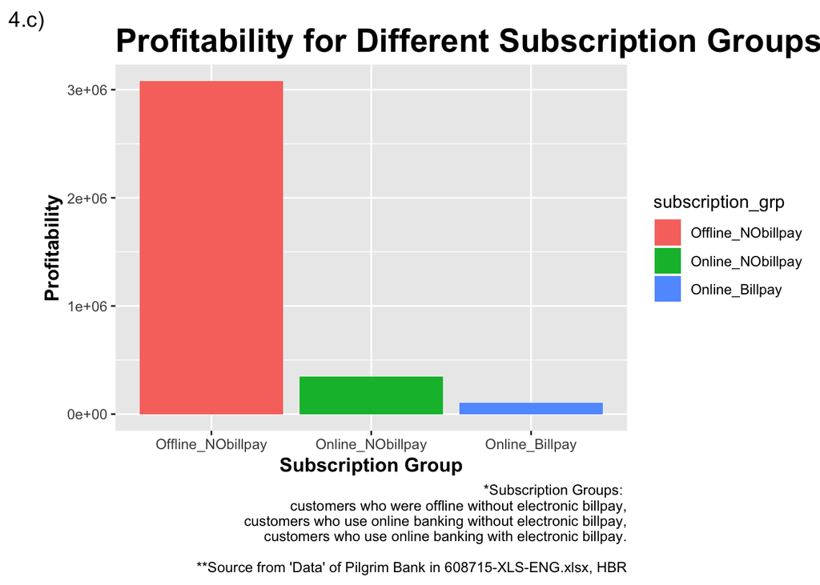

```r
pbdata_99 %>%
  group_by(subscription_grp) %>%
  summarise(totalprofit_grp = sum(Profit)) %>%
  ggplot(aes(x = subscription_grp, y = totalprofit_grp, fill = subscription_grp)) +
  geom_col() +
  labs(  #add title and anotations
      title = 'Profitability for Different Subscription Groups', tag = '4.c)', x = 'Subscription Group', y = 'Profitability',       caption = "*Subscription Groups:
customers who were offline without electronic billpay,
customers who use online banking without electronic billpay,
customers who use online banking with electronic billpay.

      **Source from 'Data' of Pilgrim Bank in 608715-XLS-ENG.xlsx, HBR"
      ) +
  theme(  #formating font and size
      plot.title = element_text(size=20, face="bold"),
      axis.title.x = element_text(size=12, face="bold"),
      axis.title.y = element_text(size=12, face="bold")
      )
```

- From 4.c), the total profit from customers who were offline is the most since customers are used to traditional way, more of them use offline banking service, which contributes to its profound totle profit. While that of the Online customers (no matter with electronical billpay or not) is far lower than the offline group.

## What do these visualizations tell you about the distribution of customer profitability? What segment(s) should Pilgrim focus on? (5 Points)

**Pilgrim should focus on customers:**

- with high income (whose income ranges from $50,000 to $99,999 and from $125,000 to more);
- who have ability to earn money, i.e. older than 24;
- who live in wealthy area (District 1200);

Beside, Pilgrim should also aim at increasing the retention rate. And due to the large market size in traditional offline market, Pilgrim should also focus on the offline market segment more compared with others.

# — 5) Statistical Analyses: —

**We want to understand whether the differences in profitability based on their subscription_grp values are statistically significant. For this analysis, compare the mean customer profitability for each pair of values in subscription_grp. (20 Points)**

- We use the ‘Independent Samples t-Test’, since we have the same variable `Profit`, three pari of sub-samples of data.
1. H0: μ“00” = μ“10”; HA: μ“00” ≠ μ“10”
2. H0: μ“00” = μ“11”; HA: μ“00” ≠ μ“11”
3. H0: μ“10” = μ“11”; HA: μ“10” ≠ μ“11”

```r
df_00 = pbdata_99 %>% filter(subscription_grp == 'Offline_NObillpay') %>% select(Profit)
df_10 = pbdata_99 %>% filter(subscription_grp == 'Online_NObillpay') %>% select(Profit)
df_11 = pbdata_99 %>% filter(subscription_grp == 'Online_Billpay') %>% select(Profit)
#test1
t.test(df_00, df_10, paired = FALSE)
```

```
##
##  Welch Two Sample t-test
##
## data:  df_00 and df_10
## t = 1.3198, df = 4147.1, p-value = 0.187
## alternative hypothesis: true difference in means is not equal to 0
## 95 percent confidence interval:
##  -3.213534 16.452298
## sample estimates:
## mean of x mean of y
##  110.7862  104.1669
```

- From Test 1, the P-value is larger than 0.05, so we should fail to reject the Null hypothesis at 95% level. Therefore, there is no significant difference between the mean of profit of the two groups (customers who were offline without billpay, customers who use online banking without billpay).
- From the perspective of economy, the mean of x or y tells that the *‘profitability per person’* of the former group(`df_00`) is relatively the same with that of the other one(`df_10`).
- And the graph 4.c) shows the total profit of the offline market(`df_00`) is greatly larger than that of the ‘customers who use online banking without billpay’(`df_10`).
- That said, people from online banking or not nearly have the same *‘profitability per person’*, it is not the online banking service that drives the profit up.

```r
#test2
t.test(df_00, df_11, paired = FALSE)
```

```
##
##  Welch Two Sample t-test
##
## data:  df_00 and df_11
## t = -5.8563, df = 540.63, p-value = 8.223e-09
## alternative hypothesis: true difference in means is not equal to 0
## 95 percent confidence interval:
##  -113.00517  -56.23672
## sample estimates:
## mean of x mean of y
##  110.7862  195.4072
```

- From Test 2, the P-value is less than 0.05, so we reject the Null hypothesis at 95% level. Therefore, there is a significant difference between the mean of profit of the two groups (customers who were offline without billpay, customers who use online banking with billpay).
- From the perspective of economy, the mean of the former group(`df_00`) is less than the later(`df_11`), which means the *‘profitability per person’* of ‘Online_Billpay’ group is higher.
- However, the Graph 4.c shows that the total profit of ‘customers who were offline without billpay’(`df_00`) is greatly larger than ‘customers who use online banking with billpay’(`df_11`).
- That said, even though the *‘total profitability’* of customers who were offline (`df_00`) is higher than the other, there are wide margins to be found in the ‘Online_Billpay’ market according to the *‘profitability per person’*.

```r
#test3
t.test(df_10, df_11, paired = FALSE)
```

```
##
##  Welch Two Sample t-test
##
## data:  df_10 and df_11
## t = -6.034, df = 647.13, p-value = 2.692e-09
## alternative hypothesis: true difference in means is not equal to 0
## 95 percent confidence interval:
##  -120.93257  -61.54808
## sample estimates:
## mean of x mean of y
##  104.1669  195.4072
```

Therefore, compared between the two Online groups, it might be the *‘electronic billpay service’* that drives online profit actually. Therefore, Pilgrim Bank shouldn’t blindly focuse on online market in general, instead, they should focuse on improving the electronic service.

# — 6) Final Reflections: —

**When you have completed the assignment, please reflect on some of the longer-lasting lessons of this experience. Most students/teams will gain key insights about Pilgrim Bank and about customer profitability patterns in general. Write a thoughtful paragraph describing the team’s one most noteworthy and valuable discovery or insight. Please be specific. (5 Points)**

```
Generally, traditional channels are more costly than electronical channels such as ATM and Online banking systems. Therefore, Pilgrim Bank should attempt to encourage customers to migrate their transactions from high cost channels to lower ones.
It seems like online banking service would generate more profit, however, based on the test results, it's actually the electronic billpay service of online banking system drives up the profit. Thus, to answer the question came up with by Green's boss, Pilgrim Bank are supposed to offer incentives such as rebates and lower service charges to ecourage greater use of the online channel.
According to the artical, at Pilgrim Bank, 10% of customers generated 70% of the profit. So Pilgrim Bank should improve their customer relationship management, focusing on specific group to maximum their profit.
On the one hand, they could keep increasing retention of a bank’s best customers:
  - 'Tiered service' strategy:
      - Offer discounts on mortgage rates
      - Offer higher interest rates on certificates of deposit
      - Route their telephone calls to specially trained personnel in the call center
      - Offer fee-waivers and rate-breaks
On the other hand, they could attract new customers from lower profit tiers (offline) to higer profit tier (online):
  - Analyse customers' behavior to break down the market. For example, to elderly customers who are not familier with the online products, Pilgrim should hold events to get them familier with the interface of online system
  - Improve the system convience by setting up a technical team to build a user-friendly interface to increase transaction volumn.
  - Forcasting behavior to create lifetime-profitability tiers by a model linking current customer characteristics to the probability of retention as well as to future revenues and costs.
  - Adopt cross-sell programs combining offline products with online products.
But there is one thing to be clarified that this relationship is derived from the statistical test, it's only a correlationship rather than a casuality since there are still other factors this dataset doesn't include.
```